# Projet régression non paramétrique

## b) h dépend localement de la fonction à estimer

Nous utilisons la fonction *h_CVloc* vue en cours pour calculer un h local en fonction des valeurs de x. Le principe est de sous sampler nos données sur plusieurs intervalles (contrôlés par la variable *N_block*) et de calculer l’estimateur et h sur chaque intervalle.

```r
h_CVloc=function(X,Y,N_block){
#N_block multiple de n
n=length(X)
h_loc=rep(-1,N_block)
if((n/N_block)%%1!=0){ print("error n should be a multiple of N_block")}
X_sort=sort(X)
Y_sort=Y[order(X)]
for(i in 1:N_block){
h_loc[i]=dpill(X_sort[((i-1)*(n/N_block)+1):(i*(n/N_block))],Y_sort[((i-1)*(n/N_block)+1):(i*(n/N_block))])
}
h_locG=rep(h_loc,each=10000/N_block)
return(list("h_loc"=h_loc,"h_locG"=h_locG))
}
```

##Nous créons une deuxième fonction *demoSKR2* qui va nous permettre de comparer les résultats d’une estimation de r(x) réalisée avec un h constant (= dpill(X,Y)) à ceux d’une estimation réalisée avec une fenêtre localisée.

```r
demoKSR2=function(X,Y, N_block){
h_CVopt=h_CVloc(X,Y,N_block)
if(length(which(is.na(h_CVopt$h_locG)))==0){h=h_CVopt$h_locG}else{h=h_CVopt$h_locG[-which(is.na(h_CVopt$h_locG))]} #on test si ce qu'on fait est raisonnable
hglobal=dpill(X,Y)
Y_CVopt=locpoly(X,Y,drv=0,degree=2,kernel="normal",gridsize=length(h),bandwidth=h)
Y_CVglobal=locpoly(X,Y,drv=0,degree=2,kernel="normal",bandwidth=hglobal)
plot(X,Y,pch=20,cex=0.01,xlab="X",ylab="Y", main = "h Global VS h Local")
lines(Y_CVopt,lty="dashed",col="blue")
lines(Y_CVglobal,lty="dashed",col="green")
legend("topleft", c("pill degré 2","hlocal degré 2"), col=c("green","blue"), lty = 1)
plot(h, main = "Evolution du h local")
}
```

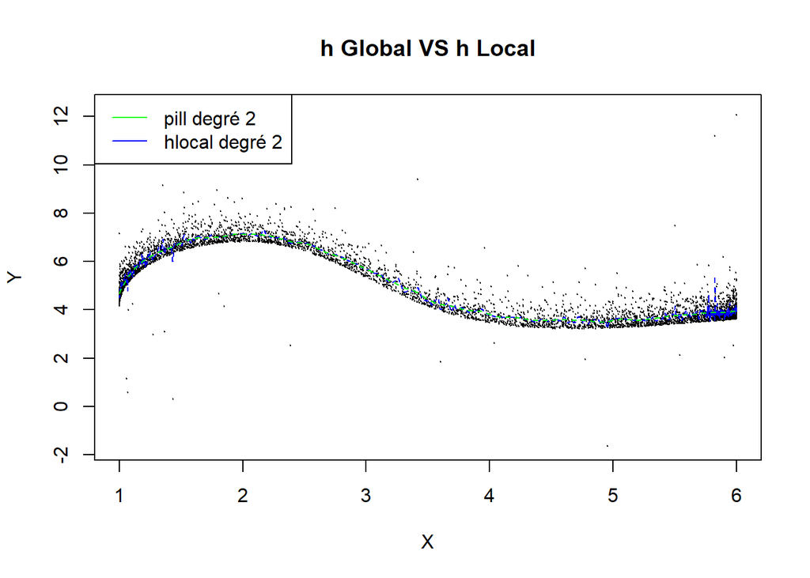

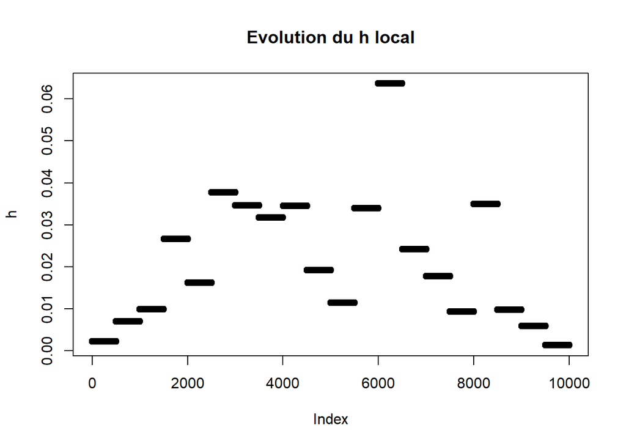

```r
demoKSR2(data$X, data$Y, 20)
```

##Etude des lois des Eps(i)

##Question 1

Nous implémentons les deux estimateurs Un et Vn :

```r
Un = sum((data$Y[2:length(data$Y)] - data$Y[1:(length(data$Y)-1)])^2)/ (2*length(data$Y) - 2)
```

```r
tildeY=data$Y[order(data$X)]
Vn = sum((tildeY[2:length(tildeY)] - tildeY[1:(length(tildeY)-1)])^2)/ (2*length(tildeY) - 2)
```

```r
tildeY=data$Y[order(data$X)]
Vn = sum((tildeY[2:length(tildeY)] - tildeY[1:(length(tildeY)-1)])^2)/ (2*length(tildeY) - 2)
```

```r
print(paste0("Un = ", Un))
```

```
## [1] "Un = 1.85033508510957"
```

```r
print(paste0("Vn = ", Vn))
```

```
## [1] "Vn = 0.194974920564902"
```